# HW3_Nicole_Black

## HW3

```python
import pandas as pd
import numpy as np
import matplotlib.pyplot as plt
from copy import copy
```

### Problem 1

In class we considered how numerical instabilities and Turing patterns could in emerge in three parts: first in a single cell, then in a pair of cells, and finally in N cells with arbitrary chemistry. In this question we will simulate the two-cell system, following in Turing's steps. Recall that: $dX_1/dt = 5 X_1 - 6 Y_1 +1 + D_x(X_2 - X_1)$\ $dY_1/dt = 6 X_1 - 7 Y_1 +1 + D_y(Y_2 - Y_1)$ \ $dX_2/dt = 5 X_2 - 6 Y_2 +1 + D_x(X_1 - X_2)$ \ $dY_2/dt = 6 X_2 - 7 Y_2 +1 + D_y(Y_1 - Y_2)$

i) Turn these equations into python code.

```python
# X1_updated = X1 + dt * (5*X1 - 6*Y1 + 1 + Dx*(X2 - X1))
# Y1_updated = Y1 + dt * (6*X1 - 7*Y1 + 1 + Dy*(Y2-Y1))
# X2_updated = X2 + dt * (5*X2 - 6*Y2 + 1 + Dx*(X1 - X2))
# Y2_updated = Y2 + dt * (6*X2 - 7*Y2 + 1 + Dy*(Y1-Y2))
```

ii) Integrate the dynamics of this system with $D_x = 0.5$, $D_y=4.5$, and the initial conditions from Turing's original paper: $X_1 = 1.06, X_2 = 0.94, Y_1 = 1.02, Y_2 = 0.98$. Use a small dt =0.001 and 1000 steps. Plot the dynamics of $X_1$ and $X_2$ over time. Would you describe the trajectory as stable or unstable? Why?

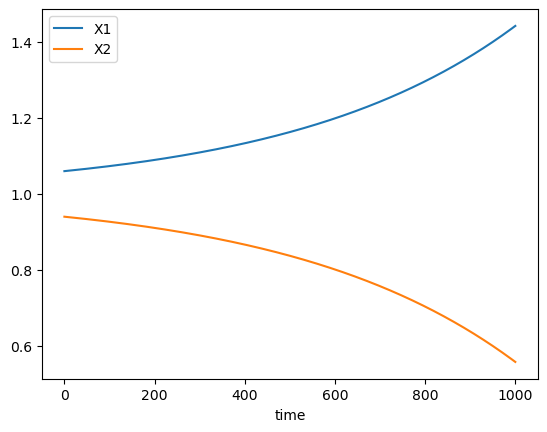

```python
Dx = 0.5
Dy = 4.5
X1 = 1.06
X2 = 0.94
Y1 = 1.02
Y2 = 0.98
dt = 0.001

X1_all = [X1]
X2_all = [X2]
Y1_all = [Y1]
Y2_all = [Y2]

for i in range(1000):
    X1_updated = X1 + dt * (5*X1 - 6*Y1 + 1 + Dx*(X2 - X1))
    X2_updated = X2 + dt * (5*X2 - 6*Y2 + 1 + Dx*(X1 - X2))
    Y1_updated = Y1 + dt * (6*X1 - 7*Y1 + 1 + Dy*(Y2-Y1))
    Y2_updated = Y2 + dt * (6*X2 - 7*Y2 + 1 + Dy*(Y1-Y2))
    X1_all.append(copy(X1_updated))
    X2_all.append(copy(X2_updated))
    Y1_all.append(copy(Y1_updated))
    Y2_all.append(copy(Y2_updated))
    X1 = copy(X1_updated)
    X2 = copy(X2_updated)
    Y1 = copy(Y1_updated)
    Y2 = copy(Y2_updated)

plt.plot(range(1001),X1_all, label="X1")
plt.plot(range(1001),X2_all, label="X2")
plt.legend()
plt.xlabel('time')
```

I would describe the above system as unstable because the $X_1$ and $X_2$ populations do not reach an equilibrium but rather seem to diverge and continue along their respective trajectories.

iii) Integrate the dynamics from the same starting point, but assume a higher diffusion coefficient $D_x=4.5$. Would you describe the trajectory as stable or unstable? Why?

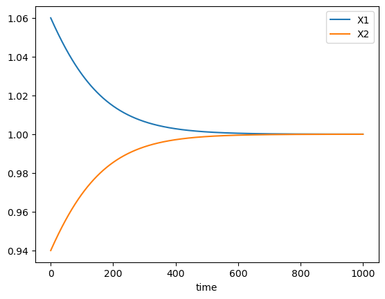

```python
Dx = 4.5
Dy = 4.5
X1 = 1.06
X2 = 0.94
Y1 = 1.02
Y2 = 0.98
dt = 0.001

X1_all = [X1]
X2_all = [X2]
Y1_all = [Y1]
Y2_all = [Y2]

for i in range(1000):
    X1_updated = X1 + dt * (5*X1 - 6*Y1 + 1 + Dx*(X2 - X1))
    X2_updated = X2 + dt * (5*X2 - 6*Y2 + 1 + Dx*(X1 - X2))
    Y1_updated = Y1 + dt * (6*X1 - 7*Y1 + 1 + Dy*(Y2-Y1))
    Y2_updated = Y2 + dt * (6*X2 - 7*Y2 + 1 + Dy*(Y1-Y2))
    X1_all.append(copy(X1_updated))
    X2_all.append(copy(X2_updated))
    Y1_all.append(copy(Y1_updated))
    Y2_all.append(copy(Y2_updated))
    X1 = copy(X1_updated)
    X2 = copy(X2_updated)
    Y1 = copy(Y1_updated)
    Y2 = copy(Y2_updated)

plt.plot(range(1001),X1_all, label="X1")
plt.plot(range(1001),X2_all, label="X2")
plt.legend()
plt.xlabel('time')
```

I would describe the above system as stable beacuse the $X_1$ and $X_2$ populations reach an equilibrium around time step t=700 when they converge to the value of ~1.

iv) Try integrating the dynamics for diffusion coefficients between these two extremes. Describe the behavior (no plots required).

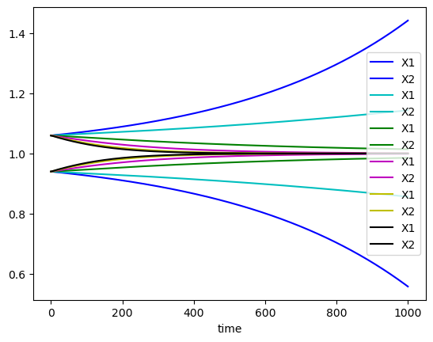

```python
Dy = 4.5
X1 = 1.06
X2 = 0.94
Y1 = 1.02
Y2 = 0.98
dt = 0.001

Dx = [0.5, 1, 2, 3, 4, 4.5]
cols = ["b", "c", "g", "m", "y", "k"]

for j in range(len(Dx)):
    X1 = 1.06
    X2 = 0.94
    Y1 = 1.02
    Y2 = 0.98

    X1_all = [X1]
    X2_all = [X2]
    Y1_all = [Y1]
    Y2_all = [Y2]
    for i in range(1000):
        X1_updated = X1 + dt * (5*X1 - 6*Y1 + 1 + Dx[j]*(X2 - X1))
        X2_updated = X2 + dt * (5*X2 - 6*Y2 + 1 + Dx[j]*(X1 - X2))
        Y1_updated = Y1 + dt * (6*X1 - 7*Y1 + 1 + Dy*(Y2-Y1))
        Y2_updated = Y2 + dt * (6*X2 - 7*Y2 + 1 + Dy*(Y1-Y2))
        X1_all.append(copy(X1_updated))
        X2_all.append(copy(X2_updated))
        Y1_all.append(copy(Y1_updated))
        Y2_all.append(copy(Y2_updated))
        X1 = copy(X1_updated)
        X2 = copy(X2_updated)
        Y1 = copy(Y1_updated)
        Y2 = copy(Y2_updated)

    plt.plot(range(1001),X1_all, label="X1", color=cols[j])
    plt.plot(range(1001),X2_all, label="X2", color=cols[j])
    plt.legend()
    plt.xlabel('time')
```

It appears that for Dx <2 the populations diverge over long time scales, while for Dx >=2 the populations converge and reach a stable equilibrium, though the smaller the Dx the longer it takes to converge.

v) In up to four sentences, describe a scenario where there could be a potential advantage (or disadvantage) of using a Turing-type mechanism versus a French-flag type mechanism for pattern formation. Recall that we discussed the French-flag type mechanism, which relies on setting up a gradient of a single morphogen, in the context of fly embryogenesis.

An advantage of the French-flag mechanism is its simplicity in only using a single morphogen and its distinction in creating sharp/crisp boundaries between its patterned areas. An advantage of the Turing-type mechanism is that it allows for much more complexity of pattern.

### Problem 2

In class we will talk about how molecular dynamics can be used to simulate polymer behavior, which can then be compared with the results of Hi-C experiments.

This question involves coding up a particle dynamics simulation in 2D.

#### a. Modelling the dynamics of 10 particles tethered to the origin (0,0) by a weak spring.

i) Place 10 particles, each of mass m=1, randomly within a 20x20 square (x, y $\in$ (-10,10)). Set initial velocities to zero.

```python
### initialization ###
# your variables may include:
# inital positions, velocities, num_steps, dt, positions over time

num_particles = 10
num_dimensions = 2
num_steps = 10000
dt = 0.01
m=1
positions_init_a = (np.random.random((num_particles, num_dimensions))-.5) * 20
velocities_init_a = np.zeros((np.shape(positions_init_a)))

all_positions_a = []
all_positions_a.append(positions_init_a.copy())
all_velocities_a = []
all_velocities_a.append(velocities_init_a.copy())
```

ii) Tether each particle to the origin with a spring with a spring constant k=0.1 (i.e. $f(x) = -k x$). Simulate their dynamics using Euler's method with a timestep 0.01 for ~10000 timesteps, recording particle positions for each timestep $\Delta t$. \ \ Mathematically:\ $x[t+1] = x[t] + v[t] \times \Delta t$, and $v[t+1] = v[t] + f[t] \times \Delta t / m $

```python
### simulate and record ###
# you may want a function that calculates force from a set of positions
# and a loop that updates positions and velocities for num_timesteps

def spring_force(positions_curr, k=0.1):
    return (-k*positions_curr)

for tstep in range(num_steps):
    v_curr_a = all_velocities_a[tstep]+spring_force(all_positions_a[tstep])*dt/m
    p_curr_a = all_positions_a[tstep]+all_velocities_a[tstep]*dt
    all_velocities_a.append(v_curr_a.copy())
    all_positions_a.append(p_curr_a.copy())

all_positions_a = np.stack(all_positions_a, axis=2)
all_velocities_a = np.stack(all_velocities_a, axis=2)
```

iii) Record and plot the x-position as a function of time for each particle. What does it resemble?

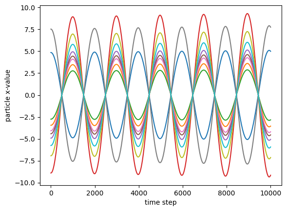

```python
### plot ###

for p in range(10):
    plt.plot(range(10001),all_positions_a[p,0,:])
plt.xlabel('time step')
plt.ylabel('particle x-value')
```

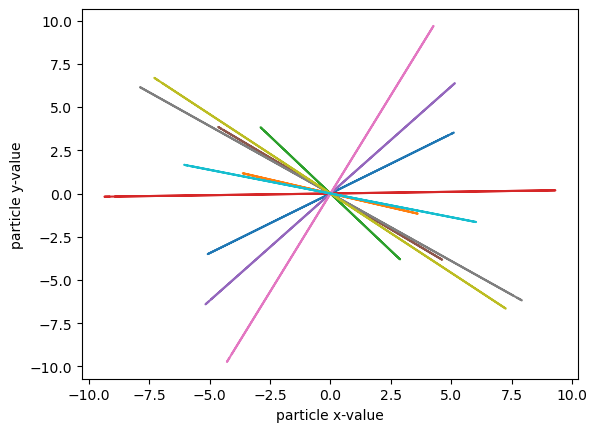

```python
### plot ###

for p in range(10):
    plt.plot(all_positions_a[p,0,:],all_positions_a[p,1,:])
plt.xlabel('particle x-value')
plt.ylabel('particle y-value')
```

The x values resemble springs oscilating around the origin of 0 (with no friction or other forces). More generally/mathematically, this is also a sine wave. The xy plot shows what this actually looks like, with each particle moving in a straight line through the origin and back.

iv) Q: For large-scale simulations, other integrators with nice properties are typically used. One example is [Vertlet Integration](https://en.wikipedia.org/wiki/Verlet_integration). What is one advantage of this integrator over Euler's method?

**A:** The Verlet integrator is symplectic, meaning it preserves properties such as convervation of energy or angular momentum over large time scales while Euler's method is non-symplectic, so it does not necessarily preserve these properties, which can lead to numerical instabilities over longer time scales.

**Extra credit:** Implement the velocity verlet integrator, as described in https://aapt-scitation-org.libproxy1.usc.edu/doi/pdf/10.1119/10.0000654/. Compare integration with larger timesteps for Euler's method and the Verlet approach. Describe your findings with up to 4 sentences and one plot.

#### b. Introduce pairwise repulsion between particles with a force $f_{ij} = \sigma^4 |r_{ij}|^{-4} \hat{r_{ij}}$, where $|r_{ij}|$ is the distance, and $\hat{r_{ij}}$ represents a unit vector in the direction between particles $i$ and $j$, and $\sigma=1$

i) If initial particle positions have overlaps, this could create a problem when you integrate their dynamics because the repulsion would be very strong. Add a check that all distances are greater than 1 before integrating the dynamics or generate an initial conformation where particles are non-overlapping. Simulate your system recording particle positions over time.

```python
def spring_force(positions_curr, k=0.1):
    forces = np.zeros((np.shape(positions_init_b)))
    forces = -k*positions_curr
    return forces

def distance(p1, p2):
    return ((p1[0] - p2[0])**2 + (p1[1] - p2[1])**2)**0.5

def unit_vec(p1, p2):
    x = p1[0] - p2[0]
    y = p1[1] - p2[1]
    magnitude = (x**2 + y**2)**0.5
    if magnitude == 0:
        return (0,0)
    else:
        return (x/magnitude, y/magnitude)

def repulsive_force(positions_curr, sigma=1):
    forces = np.zeros((np.shape(positions_init_b)))
    for i in range(num_particles):
        for j in range(num_particles):
            if i!= j:
                force_dir = unit_vec(positions_curr[i], positions_curr[j])
                dist = distance(positions_curr[i], positions_curr[j])
                forces[i, 0] += sigma**4 * (dist**(-4)) * force_dir[0]
                forces[i, 1] += sigma**4 * (dist**(-4)) * force_dir[1]
    return forces
```

```python
# initialize & simulate
# you might need some of the same variables as previously
# as well as a new function for the new force
num_particles = 10
num_dimensions = 2
num_steps = 10000
dt = 0.01
m=1

curr = (np.random.random(num_dimensions)-.5) * 20
positions_init_b = np.zeros([10, 2])
positions_init_b[0, :] = curr.copy()
counter = 1
while counter < num_particles:
    curr = (np.random.random(num_dimensions)-.5) * 20
    if all(distance(curr, existing_position) >= 1 for existing_position in positions_init_b):
        positions_init_b[counter, :] = curr.copy()
        counter += 1
velocities_init_b = np.zeros([num_particles, num_dimensions])

all_positions_b = []
all_positions_b.append(positions_init_b.copy())
all_velocities_b = []
all_velocities_b.append(velocities_init_b.copy())
```

```python
for tstep in range(num_steps):
    v_curr_b = np.zeros([num_particles, num_dimensions])
    p_curr_b = np.zeros([num_particles, num_dimensions])
    v_curr_b[:,0] = (all_velocities_b[tstep]+spring_force(all_positions_b[tstep])*dt/m-repulsive_force(all_positions_b[tstep])[0]*dt/m)[:,0]
    v_curr_b[:,1] = (all_velocities_b[tstep]+spring_force(all_positions_b[tstep])*dt/m-repulsive_force(all_positions_b[tstep])[1]*dt/m)[:,1]
    p_curr_b[:,0] = (all_positions_b[tstep]+all_velocities_b[tstep]*dt)[:,0]
    p_curr_b[:,1] = (all_positions_b[tstep]+all_velocities_b[tstep]*dt)[:,1]
    all_velocities_b.append(v_curr_b.copy())
    all_positions_b.append(p_curr_b.copy())

all_positions_b = np.stack(all_positions_b, axis=2)
all_velocities_b = np.stack(all_velocities_b, axis=2)
```

ii) Record and plot the x and y positions as a function of time for each particle. How did this change from (a)?

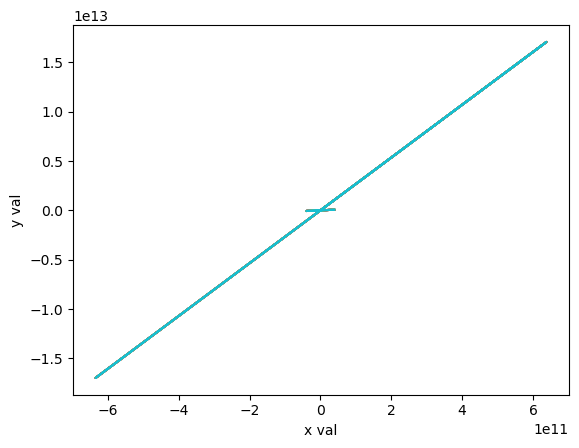

```python
### plot ###

%matplotlib inline
for particle in range(num_particles):
    plt.plot(all_positions_b[particle, 0, :], all_positions_b[particle, 1,:])
plt.xlabel("x val")
plt.ylabel("y val")
```

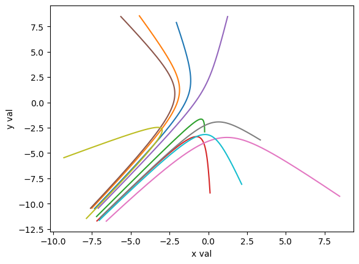

```python
%matplotlib inline
for particle in range(num_particles):
    plt.plot(all_positions_b[particle, 0, :475], all_positions_b[particle, 1,:475])
plt.xlabel("x val")
plt.ylabel("y val")
```

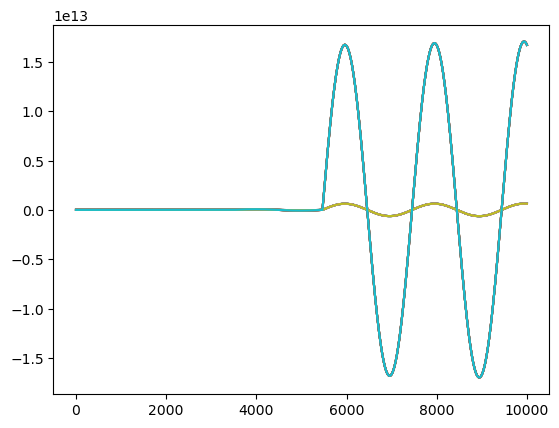

```python
for particle in range(num_particles):
    plt.plot(range(10001), all_positions_b[particle, 0,:])
    plt.plot(range(10001), all_positions_b[particle, 1,:])
```

iii) Animate your trajectory with the code below & describe the outcome in a sentence or two.

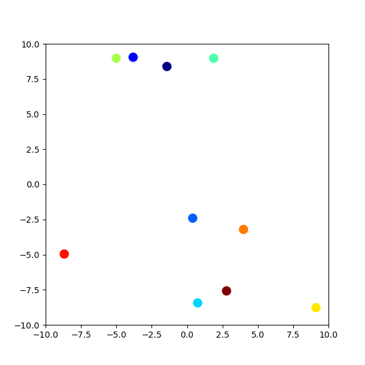

```python
# Animate

# make_animation() assumes that positions over time are recorded in an array all_positions,
# with dimensions (num_particles, num_dimensions, num_steps)
# feel free to modify!

import matplotlib.animation as animation
%matplotlib widget
def make_animation(all_positions, animation_stepsize=10):
    fig, ax = plt.subplots(figsize=(6,6))
    center_of_mass = np.mean(all_positions[:,:,0], axis=0)
    scat = ax.scatter( all_positions[:,0,0]-center_of_mass[0],
                       all_positions[:,1,0]-center_of_mass[1],
                       s=100, c=np.arange(0,255,255/10), cmap='jet')
    def animate(i):
        center_of_mass = np.mean(all_positions[:,:,i], axis=0)
        scat.set_offsets(   all_positions[:,:,i] -  center_of_mass[None,:])
        return scat,

    plt.xlim([-10,10])
    plt.ylim([-10,10])
    ani = animation.FuncAnimation(
        fig, animate, interval=20, frames= np.arange(0,  num_steps, animation_stepsize))#, blit=True)# save_count=1)
    plt.show()
    return ani


make_animation(all_positions_b, animation_stepsize=20)
```

iv) What happens to your simulation if you increase the timestep? What happens if you decrease it? How is this behavior reflected in the mean kinetic energy, $\frac{1}{2} m v^2$, over time?

When we increase the timestep the animation will update less frequently. If you don't update frequently enough, you will miss some of the dynamics of the system and this can also lead to numerical instabilities. This can decrease the mean kinetic energy because in a given time we are updating the kinetics of the system a fewer number of times.

v) **Q:** For larger systems of particles, [neighbors lists](https://hoomd-blue.readthedocs.io/en/stable/nlist.html) are used. What is one reason for this?

**A:** neighborhood lists reduce the computational intensity of a program since we do not have to compute pairwise interactions for every pair of particles, only the ones that are near to each other (ie neighbors).

vi) **Q:** What computational limitations might you encounter if you tried to develop simulations that could be compared with Hi-C data?

**A:** Hi-C outputs a large amount of data in 3D, so purely computationally, it would be very diffiuclt (and resource intensive) to simulate each individual interaction.

Congratulations! \ You've successfully simulated a system of interacting particles! Implementing a polymer is only slightly more involved-- rather than connecting all particles to the center, beads along the polymer are typically connected by springs to their neighbors.